# Your BBOB Fitness Function May Be Burning More Energy Than You Think

## Energy Scaling with Chromosome Size

One more analysis the existing data allows us to perform is to see **how energy scales** as chromosome size grows from 128 to 256 to 512 dimensions. Theory predicts linear scaling for simple element-wise functions, but loop-heavy or transcendental functions might scale super-linearly.

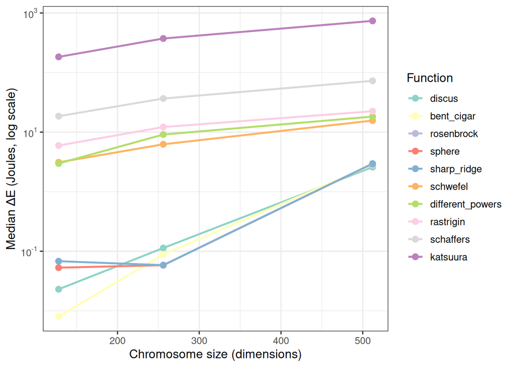

**Figure 6.** Median ΔE as a function of chromosome size, for each BBOB function (double precision, variable vector). Lines connect medians across sizes. Functions with near-zero measurements at size 128 are excluded from the log scale.

## Summary: What Should You Actually Do?

[output not shown]

## Open Questions and Future Work

The paper identified several open questions that remain fertile ground for further investigation:

1. **Compiler-fused functions**: `bent_cigar`, `discus`, `rosenbrock` (at small sizes) produce zero delta energy because the compiler merges them with the generation loop. Techniques like `volatile` fencing or separate compilation units could make these measurable.
2. **Reduced precision beyond `float`**: The transprecision computing literature suggests 8-bit and 16-bit floating-point formats can cut energy by up to 30% in some workloads. Could BBOB functions tolerate such reduced precision? The answer likely varies by function — `katsuura` with its iterated products might be sensitive, while `sphere` could be fine.
3. **Other BBOB functions**: 14 of the 24 BBOB functions remain unmeasured. Do any of them approach `katsuura`’s extreme energy footprint?
4. **Other architectures**: All results here are for an AMD Ryzen on Linux. Intel, ARM and RISC-V CPUs vectorise differently, and the float-vs-double story may be completely different on an M-series Apple chip.
5. **Algorithm-level impact**: The paper measures function calls in isolation. A full evolutionary algorithm adds selection, crossover, mutation, and population management. How does function energy cost translate to total run energy?

## References

This post is based on:

> Merelo-Guervós, J. J., Romero López, G., & García-Valdez, M. (2025). *Measuring Energy Consumption of BBOB Fitness Functions.* In *Applications of Evolutionary Computation* (EvoStar 2025), Lecture Notes in Computer Science, vol. 15613, pp. 240–254. Springer. https://doi.org/10.1007/978-3-031-90065-5_15

Source code and data: https://github.com/JJ/energy-bbob (GPL licence).